# Data606Practice2

Anthony Pagan

September 9, 2018

## Week 2 Practice

2.5 Coin ???ips. If you ???ip a fair coin 10 times, what is the probability of

##### (a) getting all tails?

```r
(1/2)^10
```

The probabilty of getting all tails is 9.76562510^{-4}

##### (b) getting all heads?

```r
(1/2)^10
```

The probabilty of getting all heads is 9.76562510^{-4}

##### (c) getting at least one tails?

We use the complement of probability of getting all heads. 1 minus that probability gives us the probability of getting at least 1 tail.

```r
1-((1/2)^10)
```

We use the complement of probability of getting all heads. 1 minus that probability gives us the probability of getting at least 1 tail which equates to 0.9990234

##### (a) Are being Independent and being a swing voter disjoint, i.e. mutually exclusive?

No, because being mutually exclusives means being one or the other. In this case some voters are both, which is opposite of being mutually exclusive.

##### (b) Draw a Venn diagram summarizing the variables and their associated probabilities.

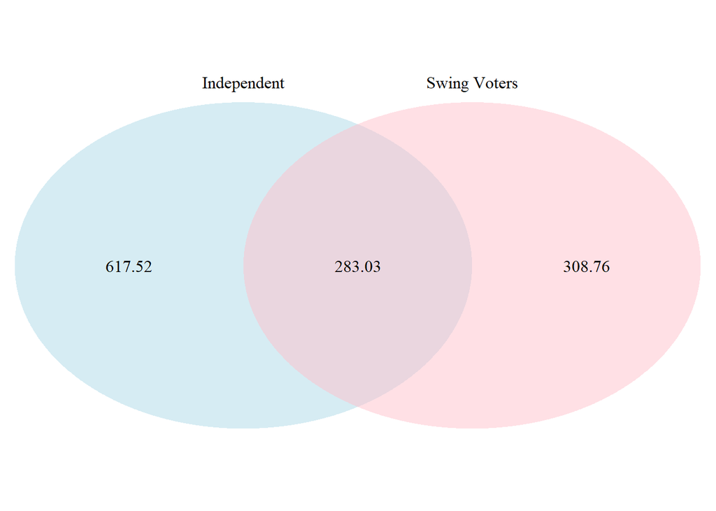

```
## (polygon[GRID.polygon.1], polygon[GRID.polygon.2], polygon[GRID.polygon.3], polygon[GRID.polygon.4], text[GRID.text.5], text[GRID.text.6], text[GRID.text.7], text[GRID.text.8], text[GRID.text.9])
```

```r
library(VennDiagram)
grid.newpage()
draw.pairwise.venn(.35*2573, .23*2573, .11*2573, category = c("Independent", "Swing Voters"), lty = rep("blank",
    2), fill = c("light blue", "pink"), alpha = rep(0.5, 2), cat.pos = c(0,
    0), cat.dist = rep(0.025, 2), scaled = FALSE )
```

##### (c) What percent of voters are Independent but not swing voters?

This would be the percent Independent and complementary of swing voters percent.

```r
(.35*(1-.23))
```

##### (d) What percent of voters are Independent or swing voters?

This would be the percent of independent voters plus swing voters

```r
.35+.23
```

##### (e) What percent of voters are neither Independent nor swing voters?

This would be the complement of Indendent plus, Swing plus voters that are both.

```r
1-(.35+.23+.11)
```

##### (f) Is the event that someone is a swing voter independent of the event that someone is a political Independent?

Yes A swing voter is not dependent on being in the independent party. If a person is classified as a swing voter they can be independent or Democrat or Republican.

##### (a) Are being female and liking Five Guys Burgers mutually exclusive?

Yes they are mutually exclusive. You can be female and like Five Guys Burgers at the same time.

##### (b) What is the probability that a randomly chosen male likes In-N-Out the best?

The probability would be total males that liked In-N-Out by total number male

```r
162/248
```

The result is 0.6532258

##### (c) What is the probability that a randomly chosen female likes In-N-Out the best?

The probability would be total females that liked In-N-Out by total number female

```r
181/252
```

The result is 0.718254

##### (d) What is the probability that a man and a woman who are dating both like In-N-Out the best? Note any assumption you make and evaluate whether you think that assumption is reasonable.

The probability would be total that liked In-N-Out by total number male and females

```r
(162+181)/500
```

The result is 0.686

##### (e) What is the probability that a randomly chosen person likes Umami best or that person is female?

The probability would be total that liked Unami by total number male and females plus total females by total females plus males.

```r
(6/550)+(252/500)
```

The result is 0.5149091

2.29 Chips in a bag. Imagine you have a bag containing 5 red, 3 blue, and 2 orange chips.

##### (a) Suppose you draw a chip and it is blue. If drawing without replacement, what is the probability the next is also blue?

Without replacment there would be 2 blue chips left and 9 chips total

```r
2/9
```

The probablity would be 0.2222222

##### (b) Suppose you draw a chip and it is orange, and then you draw a second chip without replacement. What is the probability this second chip is blue?

Without replacment after selecting an orange chip there would be 3 blue chips left, and 9 chips total

```r
3/9
```

The probablity would be 0.3333333

##### (c) If drawing without replacement, what is the probability of drawing two blue chips in a row?

Without replacment there would be 3 blue chips out of 10 chips at the start and 2 chips left and 9 chips total for second drawing

```r
(3/10)*(2/9)
```

The probablity would be 0.0666667

##### (d) When drawing without replacement, are the draws independent? Explain.

Without replacement the draws are not independent as the number of chips change and affect the next drawing. The second drawing results depend on the first drawing.

##### (a) What fraction of these cats weigh less than 2.5 kg?

The fraction will be total below 2.5 divided by total cats

```r
(35+30)/(47+97)
```

The results is 0.4513889

##### (b) What fraction of these cats weigh between 2.5 and 2.75 kg?

The fraction will be total below 2.75 divided by total cats minus total below 2.5 divided by total cats.

```r
(35+30+20)/(47+97) - (35+30)/(47+97)
```

The results is 0.1388889

##### (c) What fraction of these cats weigh between 2.75 and 3.5 kg?

The fraction will be total below 3.5 divided by total cats minus total below 2.75 divided by total cats.

```r
(35+30+20+25+10+15)/(47+97) - (35+30+20)/(47+97)
```

The results is 0.3472222